# 线性回归分析

Humoon

2021-02-18

# 1 一元线性回归

## 1.1 探索性数据分析

```
# [1] 0.9882517
```

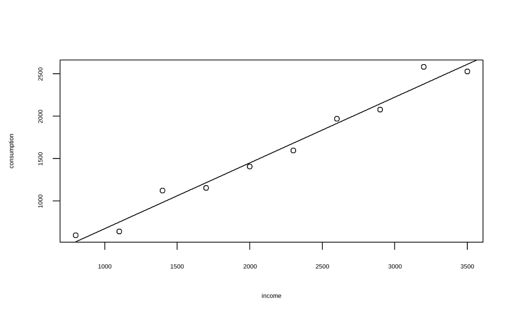

```r
# data
consumption <-
  c(594, 638, 1122, 1155, 1408, 1595, 1969, 2078, 2585, 2530)
income <-
  c(800, 1100, 1400, 1700, 2000, 2300, 2600, 2900, 3200, 3500)

# 先画图
plot(income, consumption)
abline(lm(consumption ~ income))
cor(income, consumption) # 相关系数
```

## 1.2 线性回归模型的创建和查看

语法：`lm(formula, data, ...)`

formula 为回归表达式，一般是`y~x`，默认包含截距项；不需要截距项时要写成`y~-1+x`或`y~0+x`

```r
# 有截距项回归
lm_single <- lm(consumption ~ income)
lm_single # 显示最基本的两个系数
```

```
#
# Call:
# lm(formula = consumption ~ income)
#
# Coefficients:
# (Intercept)       income
#    -103.172        0.777
```

```r
class(lm_single) # lm 类对象
```

```
# [1] "lm"
```

```r
str(lm_single) # 长度为12的列表，可以逐项展开观察
```

```
# List of 12
#  $ coefficients : Named num [1:2] -103.172 0.777
#   ..- attr(*, "names")= chr [1:2] "(Intercept)" "income"
#  $ residuals    : Named num [1:10] 75.6 -113.5 137.4 -62.7 -42.8 ...
#   ..- attr(*, "names")= chr [1:10] "1" "2" "3" "4" ...
#  $ effects      : Named num [1:10] -4956.6 2117.3 135.4 -76.1 -67.7 ...
#   ..- attr(*, "names")= chr [1:10] "(Intercept)" "income" "" "" ...
#  $ rank         : int 2
#  $ fitted.values: Named num [1:10] 518 752 985 1218 1451 ...
#   ..- attr(*, "names")= chr [1:10] "1" "2" "3" "4" ...
#  $ assign       : int [1:2] 0 1
#  $ qr           :List of 5
#   ..$ qr   : num [1:10, 1:2] -3.162 0.316 0.316 0.316 0.316 ...
#   .. ..- attr(*, "dimnames")=List of 2
#   .. .. ..$ : chr [1:10] "1" "2" "3" "4" ...
#   .. .. ..$ : chr [1:2] "(Intercept)" "income"
#   .. ..- attr(*, "assign")= int [1:2] 0 1
#   ..$ qraux: num [1:2] 1.32 1.27
#   ..$ pivot: int [1:2] 1 2
#   ..$ tol  : num 1e-07
#   ..$ rank : int 2
#   ..- attr(*, "class")= chr "qr"
#  $ df.residual  : int 8
#  $ xlevels      : Named list()
#  $ call         : language lm(formula = consumption ~ income)
#  $ terms        :Classes 'terms', 'formula'  language consumption ~ income
#   .. ..- attr(*, "variables")= language list(consumption, income)
#   .. ..- attr(*, "factors")= int [1:2, 1] 0 1
#   .. .. ..- attr(*, "dimnames")=List of 2
#   .. .. .. ..$ : chr [1:2] "consumption" "income"
#   .. .. .. ..$ : chr "income"
#   .. ..- attr(*, "term.labels")= chr "income"
#   .. ..- attr(*, "order")= int 1
#   .. ..- attr(*, "intercept")= int 1
#   .. ..- attr(*, "response")= int 1
#   .. ..- attr(*, ".Environment")=<environment: R_GlobalEnv>
#   .. ..- attr(*, "predvars")= language list(consumption, income)
#   .. ..- attr(*, "dataClasses")= Named chr [1:2] "numeric" "numeric"
#   .. .. ..- attr(*, "names")= chr [1:2] "consumption" "income"
#  $ model        :'data.frame':    10 obs. of  2 variables:
#   ..$ consumption: num [1:10] 594 638 1122 1155 1408 ...
#   ..$ income     : num [1:10] 800 1100 1400 1700 2000 2300 2600 2900 3200 3500
#   ..- attr(*, "terms")=Classes 'terms', 'formula'  language consumption ~ income
#   .. .. ..- attr(*, "variables")= language list(consumption, income)
#   .. .. ..- attr(*, "factors")= int [1:2, 1] 0 1
#   .. .. .. ..- attr(*, "dimnames")=List of 2
#   .. .. .. .. ..$ : chr [1:2] "consumption" "income"
#   .. .. .. .. ..$ : chr "income"
#   .. .. ..- attr(*, "term.labels")= chr "income"
#   .. .. ..- attr(*, "order")= int 1
#   .. .. ..- attr(*, "intercept")= int 1
#   .. .. ..- attr(*, "response")= int 1
#   .. .. ..- attr(*, ".Environment")=<environment: R_GlobalEnv>
#   .. .. ..- attr(*, "predvars")= language list(consumption, income)
#   .. .. ..- attr(*, "dataClasses")= Named chr [1:2] "numeric" "numeric"
#   .. .. .. ..- attr(*, "names")= chr [1:2] "consumption" "income"
#  - attr(*, "class")= chr "lm"
```

```r
# 返回系数向量的两种写法
coef(lm_single)
```

```
#  (Intercept)       income
# -103.1717172    0.7770101
```

```r
lm_single$coefficients
```

```
#  (Intercept)       income
# -103.1717172    0.7770101
```

```r
# 概览回归结果
slm_single <- summary(lm_single)
class(slm_single) # summary.lm 类的对象
```

```
# [1] "summary.lm"
```

```r
slm_single
```

```
#
# Call:
# lm(formula = consumption ~ income)
#
# Residuals:
#     Min      1Q  Median      3Q     Max
# -113.54  -82.81  -52.80   69.66  201.74
#
# Coefficients:
#               Estimate Std. Error t value Pr(>|t|)
# (Intercept) -103.17172   98.40598  -1.048    0.325
# income         0.77701    0.04249  18.289 8.22e-08 ***
# ---
# Signif. codes:  0 '***' 0.001 '**' 0.01 '*' 0.05 '.' 0.1 ' ' 1
#
# Residual standard error: 115.8 on 8 degrees of freedom
# Multiple R-squared:  0.9766,  Adjusted R-squared:  0.9737
# F-statistic: 334.5 on 1 and 8 DF,  p-value: 8.217e-08
```

```r
# 系数详情
coef(slm_single)
```

```
#                 Estimate Std. Error   t value     Pr(>|t|)
# (Intercept) -103.1717172 98.4059798 -1.048429 3.250795e-01
# income         0.7770101  0.0424851 18.289003 8.217449e-08
```

```r
slm_single$coefficients # 这是一个矩阵
```

```
#                 Estimate Std. Error   t value     Pr(>|t|)
# (Intercept) -103.1717172 98.4059798 -1.048429 3.250795e-01
# income         0.7770101  0.0424851 18.289003 8.217449e-08
```

```r
slm_single$coef[, 2] # 第二列为系数的标准误
```

```
# (Intercept)      income
#  98.4059798   0.0424851
```

```r
# 对\sigma的估计，有了这个参数才能计算系数的标准误
slm_single$sigma
```

```
# [1] 115.767
```

```r
# 模型系数的置信区间
confint(lm_single, level = 0.95) # 注意第一个参数是lm而非slm!
```

```
#                    2.5 %      97.5 %
# (Intercept) -330.0963136 123.7528793
# income         0.6790393   0.8749809
```

```r
## 截距项不显著，故使用无截距项回归
lm(consumption ~ -1 + income) %>% summary()
```

```
#
# Call:
# lm(formula = consumption ~ -1 + income)
#
# Residuals:
#     Min      1Q  Median      3Q     Max
# -171.23  -87.55  -50.13   43.57  230.87
#
# Coefficients:
#        Estimate Std. Error t value Pr(>|t|)
# income  0.73566    0.01589   46.29 5.13e-12 ***
# ---
# Signif. codes:  0 '***' 0.001 '**' 0.01 '*' 0.05 '.' 0.1 ' ' 1
#
# Residual standard error: 116.4 on 9 degrees of freedom
# Multiple R-squared:  0.9958,  Adjusted R-squared:  0.9954
# F-statistic:  2143 on 1 and 9 DF,  p-value: 5.128e-12
```

```r
# R^2更大了，所以去掉截距项是正确的
```

## 1.3 OLS和MLE两种参数估计方法

```r
## 首先定义一个回调函数，传入模型参数向量，返回要取极值的表达式

# MLE，最大化对数似然函数(linklihood function)
mleFunction = function(para) {
  n = length(consumption)
  e = consumption - para[1] - para[2] * income # 残差
  return(-0.5 * n * log(2 * pi) - n * log(para[3]) - 0.5 * sum(e ^ 2) / (para[3] ^ 2))
  # 注意以上两行都是向量化计算
}
# maxLik()令似然函数取极值，估计出模型参数，建立回归模型
lm_mle = maxLik(mleFunction, start = c(0.1, 1, 1)) %T>% class()
coef(lm_mle) # 传入的3个参数，分别为截距项、一次项系数和\sigma的估计量
```

```
# [1] -103.1722500    0.7770027  103.5427630
```

```r
# OLS，最小化残差平方和
olsFunction = function(para) {
  e = consumption - para[1] - para[2] * income
  return(sum(e ^ 2))
}
optim(c(100, 1), olsFunction) # 这不是一个回归模型对象，但它能显示模型参数值
```

```
# $par
# [1] -103.2585229    0.7770318
#
# $value
# [1] 107216
#
# $counts
# function gradient
#       73       NA
#
# $convergence
# [1] 0
#
# $message
# NULL
```

## 1.4 模型检验

### 1.4.1 拟合优度

```r
slm_single$r.squared
```

```
# [1] 0.9766415
```

```r
slm_single$adj.r.squared
```

```
# [1] 0.9737217
```

### 1.4.2 变量显著性

看`slm$coef`展示的系数矩阵的三四列即可，使用了t检验

其实直接显示slm摘要更方面，直接给出是否显著的星号

```r
slm_single$coefficients
```

```
#                 Estimate Std. Error   t value     Pr(>|t|)
# (Intercept) -103.1717172 98.4059798 -1.048429 3.250795e-01
# income         0.7770101  0.0424851 18.289003 8.217449e-08
```

```r
slm_single
```

```
#
# Call:
# lm(formula = consumption ~ income)
#
# Residuals:
#     Min      1Q  Median      3Q     Max
# -113.54  -82.81  -52.80   69.66  201.74
#
# Coefficients:
#               Estimate Std. Error t value Pr(>|t|)
# (Intercept) -103.17172   98.40598  -1.048    0.325
# income         0.77701    0.04249  18.289 8.22e-08 ***
# ---
# Signif. codes:  0 '***' 0.001 '**' 0.01 '*' 0.05 '.' 0.1 ' ' 1
#
# Residual standard error: 115.8 on 8 degrees of freedom
# Multiple R-squared:  0.9766,  Adjusted R-squared:  0.9737
# F-statistic: 334.5 on 1 and 8 DF,  p-value: 8.217e-08
```

## 1.5 模型预测

### 1.5.1 点预测

```r
# 以下三种写法等价
slm_single$coef[, 1][1] + slm_single$coef[, 1][2] * 4000
```

```
# (Intercept)
#    3004.869
```

```r
coef(lm_single)[1] + coef(lm_single)[2] * 4000
```

```
# (Intercept)
#    3004.869
```

```r
predict(lm_single, newdata = data.frame(income = 4000))
```

```
#        1
# 3004.869
```

```r
round(fitted(lm_single), 2) # 模型在样本点处的拟合值
```

```
#       1       2       3       4       5       6       7       8       9      10
#  518.44  751.54  984.64 1217.75 1450.85 1683.95 1917.05 2150.16 2383.26 2616.36
```

```r
round(resid(lm_single), 2) # 模型在样本点处的的残差
```

```
#       1       2       3       4       5       6       7       8       9      10
#   75.56 -113.54  137.36  -62.75  -42.85  -88.95   51.95  -72.16  201.74  -86.36
```

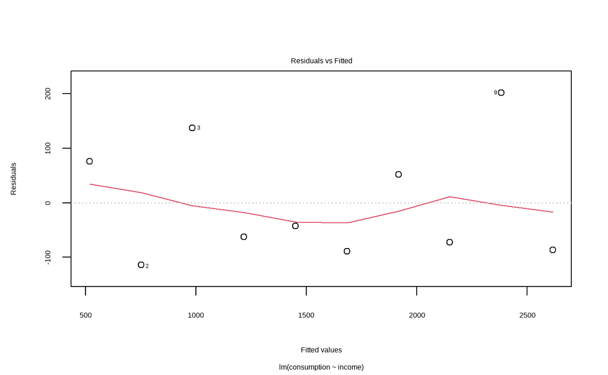

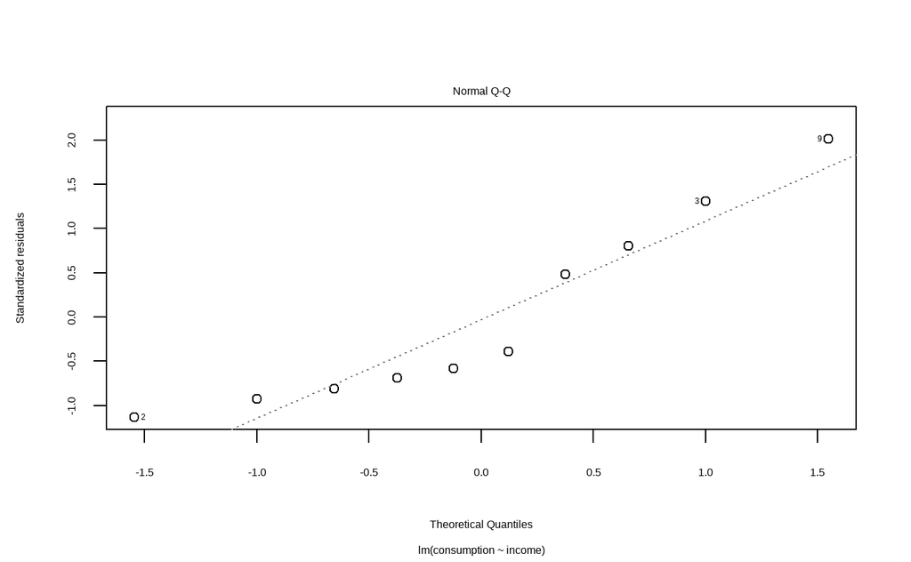

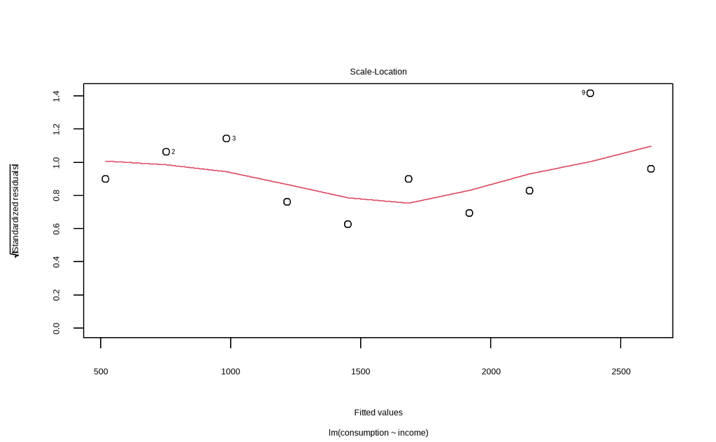

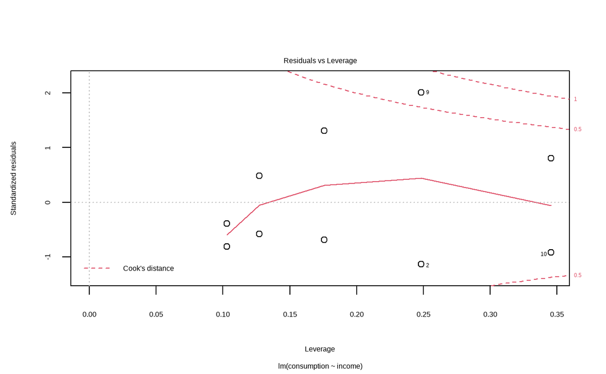

```r
plot(lm_single)
```

### 1.5.2 区间预测

拟合值的条件均值的置信区间 `predict(..., interval = "prediction", level = 0.95)`

总体的条件期望的置信区间 `predict(..., interval = "confidence", level = 0.95)`

```r
predict(
  lm_single,
  newdata = data.frame(income = 4000),
  interval = "prediction",
  level = 0.95
)
```

```
#        fit      lwr      upr
# 1 3004.869 2671.336 3338.401
```

```r
predict(
  lm_single,
  newdata = data.frame(income = 4000),
  interval = "confidence",
  level = 0.95
)
```

```
#        fit      lwr      upr
# 1 3004.869 2804.927 3204.811
```

## 1.6 作图

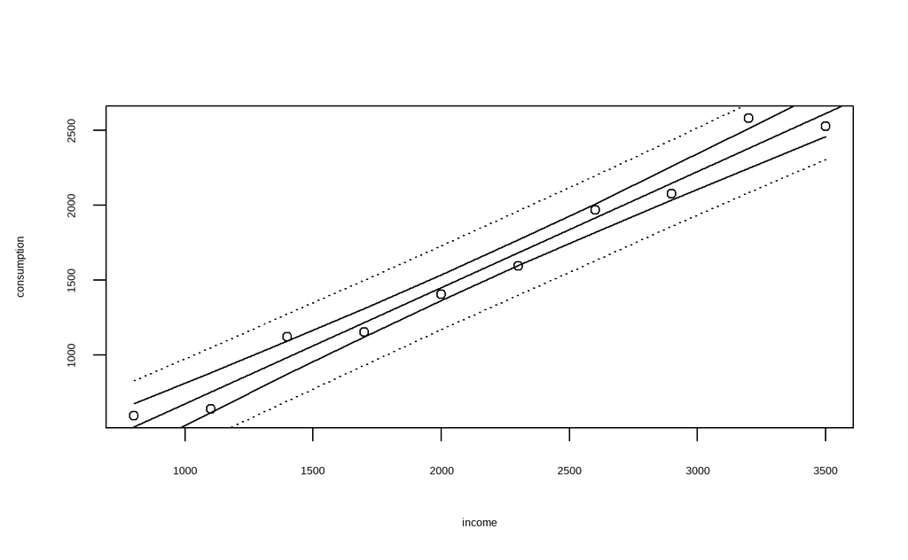

```r
par(mfrow = c(1, 1))
sx = sort(income)
prediction = predict(lm_single, data.frame(income = sx), interval = "prediction")
confidence = predict(lm_single, data.frame(income = sx), interval = "confidence")
plot(income, consumption)
abline(lm_single)
lines(sx, confidence[, 2])
lines(sx, confidence[, 3])
lines(sx, prediction[, 2], lty = 3)
lines(sx, prediction[, 3], lty = 3)
```

## 1.7 综合案例

```r
rm(list = ls())

# 探索性数据分析
data = read.table("medicine.txt", head = T)
attach(data)
plot(x, y, xlab = "人口数", ylab = "医疗机构数")
abline(lm(y ~ x));
cor(x, y)
```

```
# [1] 0.8826382
```

```r
# 建模和检验
lm = lm(y ~ x)
lm.summary = summary(lm)
lm.summary
```

```
#
# Call:
# lm(formula = y ~ x)
#
# Residuals:
#    Min     1Q Median     3Q    Max
# -650.6 -434.6 -167.7  162.6 1499.4
#
# Coefficients:
#              Estimate Std. Error t value Pr(>|t|)
# (Intercept) -587.2682   345.6418  -1.699    0.111
# x              5.3211     0.7574   7.026    6e-06 ***
# ---
# Signif. codes:  0 '***' 0.001 '**' 0.01 '*' 0.05 '.' 0.1 ' ' 1
#
# Residual standard error: 651.3 on 14 degrees of freedom
# Multiple R-squared:  0.7791,  Adjusted R-squared:  0.7633
# F-statistic: 49.36 on 1 and 14 DF,  p-value: 5.998e-06
```

```r
lm.summary$r.squared
```

```
# [1] 0.7790501
```

```r
lm.summary$adj.r.squared
```

```
# [1] 0.763268
```

```r
# 常数项不显著，重新建模
lm2 = lm(y ~ 0 + x)
lm2.summary = summary(lm2)
lm2.summary
```

```
#
# Call:
# lm(formula = y ~ 0 + x)
#
# Residuals:
#     Min      1Q  Median      3Q     Max
# -683.44 -564.47 -246.33  -86.26 2062.32
#
# Coefficients:
#   Estimate Std. Error t value Pr(>|t|)
# x   4.1860     0.3785   11.06 1.31e-08 ***
# ---
# Signif. codes:  0 '***' 0.001 '**' 0.01 '*' 0.05 '.' 0.1 ' ' 1
#
# Residual standard error: 691 on 15 degrees of freedom
# Multiple R-squared:  0.8907,  Adjusted R-squared:  0.8835
# F-statistic: 122.3 on 1 and 15 DF,  p-value: 1.309e-08
```

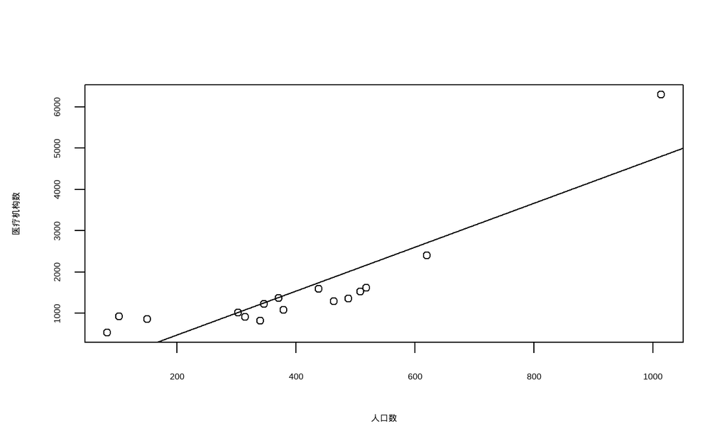

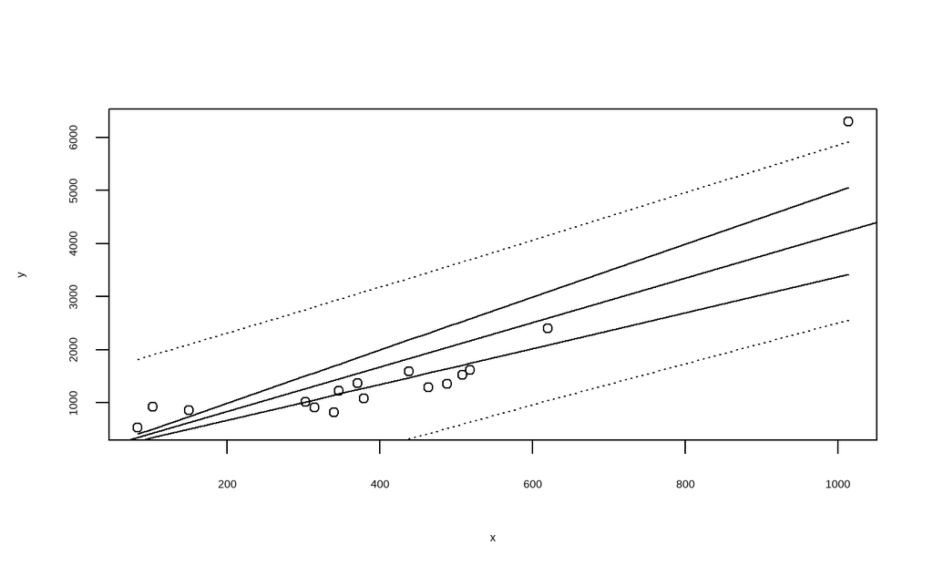

```r
# 作图
par(mfrow = c(1, 1))
sx = sort(x)
pred = predict(lm2, data.frame(x = sx), interval = "prediction")
conf = predict(lm2, data.frame(x = sx), interval = "confidence")
plot(x, y)
abline(lm2)
lines(sx, conf[, 2])
lines(sx, conf[, 3])
lines(sx, pred[, 2], lty = 3)
lines(sx, pred[, 3], lty = 3)
detach()
```

# 2 多元线性回归

## 2.1 模型建构

```r
rm(list = ls())

data <- read.csv(file = "tax.csv")
lm3 = lm(tax ~ GDP + expand + CPI, data = data)
coef(lm3)
```

```
#   (Intercept)           GDP        expand           CPI
# -6.616014e+03  4.728764e-02  6.139577e-01  5.820884e+01
```

## 2.2 最大似然估计

```r
attach(data)

## MLE
loglik = function (para) {
  N = length(tax)
  e = tax - para[1] - para[2] * GDP - para[3] * expand - para[4] * CPI
  ll = -N * log(sqrt(2 * pi) * para[5]) - 0.5 * sum(e ^ 2)/ (para[5] ^ 2)
  return(ll)
}
mle3 = maxLik(loglik,
              start = c(6616, 0.04, 0.6, 58, 100), # 结果与初始值有关，并非全局最优
              iterlim = 10000)
mle3
```

```
# Maximum Likelihood estimation
# Newton-Raphson maximisation, 61 iterations
# Return code 8: successive function values within relative tolerance limit (reltol)
# Log-Likelihood: -693.8302 (5 free parameter(s))
# Estimate(s): -1504852 153.212 -594.6736 -51959.67 1509732
```

```r
coef(mle3)
```

```
# [1] -1504852.0682      153.2120     -594.6736   -51959.6685  1509731.7780
```

```r
detach()
```

## 2.3 模型检验

### 2.3.1 拟合优度

多元回归应该用adjusted $R^2$

```r
slm3 <- summary(lm3)
slm3$r.squared # 注意是在slm对象中提取，而非lm对象
```

```
# [1] 0.9988508
```

```r
slm3$adj.r.squared
```

```
# [1] 0.9987396
```

### 2.3.2 整体显著性

F检验

```r
slm3
```

```
#
# Call:
# lm(formula = tax ~ GDP + expand + CPI, data = data)
#
# Residuals:
#      Min       1Q   Median       3Q      Max
# -2551.29  -511.58    12.51   458.76  3033.79
#
# Coefficients:
#               Estimate Std. Error t value Pr(>|t|)
# (Intercept) -6.616e+03  2.951e+03  -2.242   0.0323 *
# GDP          4.729e-02  8.995e-03   5.257 1.03e-05 ***
# expand       6.140e-01  3.880e-02  15.825  < 2e-16 ***
# CPI          5.821e+01  2.771e+01   2.101   0.0439 *
# ---
# Signif. codes:  0 '***' 0.001 '**' 0.01 '*' 0.05 '.' 0.1 ' ' 1
#
# Residual standard error: 946 on 31 degrees of freedom
# Multiple R-squared:  0.9989,  Adjusted R-squared:  0.9987
# F-statistic:  8982 on 3 and 31 DF,  p-value: < 2.2e-16
```

### 2.3.3 变量显著性

```r
slm3$coef
```

```
#                  Estimate   Std. Error   t value     Pr(>|t|)
# (Intercept) -6.616014e+03 2.951208e+03 -2.241798 3.227172e-02
# GDP          4.728764e-02 8.995209e-03  5.256980 1.027878e-05
# expand       6.139577e-01 3.879721e-02 15.824790 2.125661e-16
# CPI          5.820884e+01 2.770822e+01  2.100779 4.388931e-02
```

## 2.4 模型预测

### 2.4.1 点预测

```r
coef(lm3)[1] + coef(lm3)[2] * 520000 + coef(lm3)[3] * 130000 + coef(lm3)[4] *
  103
```

```
# (Intercept)
#    103783.6
```

```r
predict(lm3, newdata = data.frame(GDP = 520000, expand = 130000, CPI = 103))
```

```
#        1
# 103783.6
```

### 2.4.2 区间预测

拟合值的条件均值的置信区间 predict(…, interval = “prediction”)

总体的条件期望的置信区间 predict(…, interval = “confidence”)

```r
predict(lm3, interval = "prediction") # 不指定第二个参数，就是样本内拟合
```

```
#            fit        lwr        upr
# 1     106.9064 -1911.0860   2124.899
# 2     300.3629 -1708.3611   2309.087
# 3     523.5249 -1469.3811   2516.431
# 4     274.7184 -1727.2032   2276.640
# 5     322.6875 -1682.1157   2327.491
# 6     440.6120 -1567.0962   2448.320
# 7     754.7495 -1244.3930   2753.892
# 8    1375.1484  -619.7959   3370.093
# 9    1393.6963  -593.9882   3381.381
# 10   1588.5233  -396.8149   3573.862
# 11   2522.2875   417.6816   4626.893
# 12   2778.6029   687.7215   4869.484
# 13   2105.4482   118.1490   4092.747
# 14   2485.0272   505.6841   4464.370
# 15   3090.5513  1122.1105   5058.992
# 16   4490.7663  2474.6792   6506.853
# 17   6299.3617  4112.0547   8486.669
# 18   7084.1358  5019.2372   9149.034
# 19   7750.1374  5752.5721   9747.703
# 20   8611.7664  6602.3887  10621.144
# 21   9609.1781  7580.5819  11637.774
# 22  11310.8864  9291.7406  13330.032
# 23  13505.4080 11507.4507  15503.365
# 24  15873.9785 13888.2360  17859.721
# 25  18300.6543 16314.9661  20286.343
# 26  20715.8190 18733.3045  22698.334
# 27  24397.7857 22404.2075  26391.364
# 28  28766.0269 26763.5941  30768.460
# 29  34290.5364 32268.0982  36312.975
# 30  42588.1757 40501.9026  44674.449
# 31  52921.8783 50831.0835  55012.673
# 32  62072.8781 60029.7766  64115.979
# 33  73467.9373 71394.1414  75541.733
# 34  88720.8268 86547.2575  90894.396
# 35 101064.8464 98724.1693 103405.523
```

```r
predict(lm3, interval = "confidence")
```

```
#            fit         lwr         upr
# 1     106.9064  -484.77392    698.5867
# 2     300.3629  -258.89063    859.6165
# 3     523.5249    24.05868   1022.9911
# 4     274.7184  -259.58723    809.0240
# 5     322.6875  -222.31529    867.6902
# 6     440.6120  -114.98205    996.2061
# 7     754.7495   230.95263   1278.5464
# 8    1375.1484   867.61035   1882.6864
# 9    1393.6963   915.48918   1871.9034
# 10   1588.5233  1120.16408   2056.8826
# 11   2522.2875  1681.36040   3363.2145
# 12   2778.6029  1972.63943   3584.5663
# 13   2105.4482  1628.84515   2582.0512
# 14   2485.0272  2042.77020   2927.2841
# 15   3090.5513  2699.97303   3481.1295
# 16   4490.7663  3905.61724   5075.9154
# 17   6299.3617  5268.77720   7329.9462
# 18   7084.1358  6348.20206   7820.0695
# 19   7750.1374  7232.39305   8267.8817
# 20   8611.7664  8050.16943   9173.3634
# 21   9609.1781  8982.28492  10236.0713
# 22  11310.8864 10715.28402  11906.4888
# 23  13505.4080 12986.15300  14024.6629
# 24  15873.9785 15403.90869  16344.0482
# 25  18300.6543 17830.81376  18770.4949
# 26  20715.8190 20259.57746  21172.0606
# 27  24397.7857 23895.64388  24899.9275
# 28  28766.0269 28229.80924  29302.2446
# 29  34290.5364 33683.86618  34897.2067
# 30  42588.1757 41794.24381  43382.1077
# 31  52921.8783 52116.13951  53727.6171
# 32  62072.8781 61400.52711  62745.2290
# 33  73467.9373 72707.39700  74228.4776
# 34  88720.8268 87719.72943  89721.9241
# 35 101064.8464 99739.49306 102390.1997
```

```r
predict(lm3,
        newdata = data.frame(GDP = 520000, expand = 130000, CPI = 103),
        interval = "prediction")
```

```
#        fit    lwr      upr
# 1 103783.6 101335 106232.2
```

```r
predict(lm3,
        newdata = data.frame(GDP = 520000, expand = 130000, CPI = 103),
        interval = "confidence")
```

```
#        fit      lwr      upr
# 1 103783.6 102275.7 105291.4
```

## 2.5 综合案例

```r
rm(list = ls())
par(mfrow = c(2, 3))

data = read.table("travel.txt", head = 1)
attach(data)

# 探索性数据分析
plot(x1, y, xlab = "国内旅游人数", ylab = "国内旅游收入")
abline(lm(y ~ x1))
plot(x2, y, xlab = "城镇居民人均旅游支出", ylab = "国内旅游收入")
abline(lm(y ~ x2))
plot(x3, y, xlab = "农村居民人均旅游支出", ylab = "国内旅游收入")
abline(lm(y ~ x3))
plot(x4, y, xlab = "公路里程", ylab = "国内旅游收入")
abline(lm(y ~ x4))
plot(x5, y, xlab = "铁路里程", ylab = "国内旅游收入")
abline(lm(y ~ x5))
c(cor(x1, y), cor(x2, y), cor(x3, y), cor(x4, y), cor(x5, y))
```

```
# [1] 0.9506456 0.9776733 0.8783299 0.9162138 0.9515093
```

```r
pairs(data[, 3:7]) # 散点图矩阵，可以观察哪些自变量之间存在强相关，可能导致多重共线性

# 建模
lm = lm(y ~ x1 + x2 + x3 + x4 + x5)
lm.summary = summary(lm)
lm.summary
```

```
#
# Call:
# lm(formula = y ~ x1 + x2 + x3 + x4 + x5)
#
# Residuals:
#       1       2       3       4       5       6       7       8       9      10
#   47.98  -38.43   55.94  -70.41 -110.14   45.56   91.39  -34.75   53.34  -40.48
#
# Coefficients:
#               Estimate Std. Error t value Pr(>|t|)
# (Intercept) -274.37728 1316.68972  -0.208   0.8451
# x1             0.01309    0.01269   1.031   0.3607
# x2             5.43819    1.38040   3.940   0.0170 *
# x3             3.27177    0.94421   3.465   0.0257 *
# x4            12.98624    4.17793   3.108   0.0359 *
# x5          -563.10774  321.28299  -1.753   0.1545
# ---
# Signif. codes:  0 '***' 0.001 '**' 0.01 '*' 0.05 '.' 0.1 ' ' 1
#
# Residual standard error: 100.1 on 4 degrees of freedom
# Multiple R-squared:  0.9954,  Adjusted R-squared:  0.9897
# F-statistic: 173.4 on 5 and 4 DF,  p-value: 9.19e-05
```

```r
# 检验
lm.summary$r.squared
```

```
# [1] 0.9954063
```

```r
lm.summary$adj.r.squared
```

```
# [1] 0.9896642
```

```r
# 有三个系数不显著，可能存在多重共线性，下一章讨论
# 计算一下相关系数
c(cor(x1, x2), cor(x1, x3), cor(x4, x5))
```

```
# [1] 0.9188508 0.7519599 0.8977083
```

```r
# 重新建模
lm2 = lm(y ~ x2 + x3 + x4)
lm2.summary = summary(lm2)
lm2.summary
```

```
#
# Call:
# lm(formula = y ~ x2 + x3 + x4)
#
# Residuals:
#     Min      1Q  Median      3Q     Max
# -115.74  -83.44    0.28   72.99  121.55
#
# Coefficients:
#              Estimate Std. Error t value Pr(>|t|)
# (Intercept) -2441.161    296.039  -8.246 0.000172 ***
# x2              4.216      1.069   3.945 0.007581 **
# x3              3.222      1.050   3.068 0.022008 *
# x4             13.629      2.904   4.693 0.003351 **
# ---
# Signif. codes:  0 '***' 0.001 '**' 0.01 '*' 0.05 '.' 0.1 ' ' 1
#
# Residual standard error: 111.6 on 6 degrees of freedom
# Multiple R-squared:  0.9914,  Adjusted R-squared:  0.9872
# F-statistic: 231.8 on 3 and 6 DF,  p-value: 1.365e-06
```

```r
# 三项检验均通过

# 预测
conf = predict(lm2, data.frame(x2, x3, x4), interval = "confidence")
pred = predict(lm2, data.frame(x2, x3, x4), interval = "prediction")
```

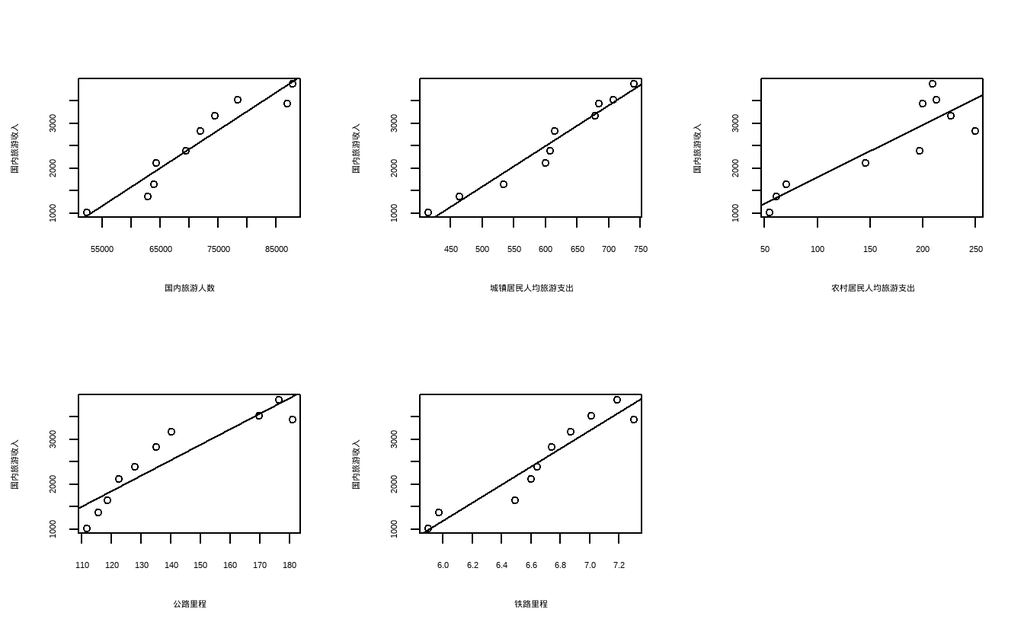

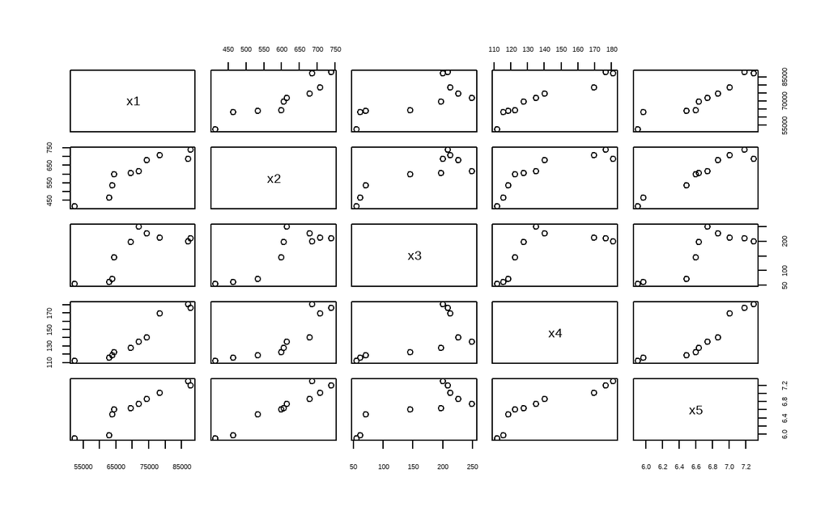

# 3 多重共线性 multicolinarity

## 3.1 原因

变量之间存在相关性

## 3.2 多重共线性的诊断

### 3.2.1 可决系数法

$R^2$较大、F值很高但每个系数的方差都很大、t值都很小。

```r
dat <- read.csv(file = "11-1.csv")
lm3 = lm(revenue ~ industry + agriculture + construction + consumption +
           pop + disaster,
         data = dat)
summary(lm3)
```

```
#
# Call:
# lm(formula = revenue ~ industry + agriculture + construction +
#     consumption + pop + disaster, data = dat)
#
# Residuals:
#      Min       1Q   Median       3Q      Max
# -1135.26  -418.22    22.56   374.25  1019.92
#
# Coefficients:
#                Estimate Std. Error t value Pr(>|t|)
# (Intercept)   6.821e+04  7.081e+04   0.963  0.36359
# industry      1.297e-01  1.032e-01   1.257  0.24426
# agriculture  -7.065e-02  7.393e-01  -0.096  0.92622
# construction  4.465e-02  2.038e-01   0.219  0.83206
# consumption   6.011e-01  1.501e-01   4.005  0.00392 **
# pop          -7.020e-01  5.007e-01  -1.402  0.19846
# disaster      4.324e-02  5.569e-02   0.776  0.45986
# ---
# Signif. codes:  0 '***' 0.001 '**' 0.01 '*' 0.05 '.' 0.1 ' ' 1
#
# Residual standard error: 811.3 on 8 degrees of freedom
# Multiple R-squared:  0.9997,  Adjusted R-squared:  0.9995
# F-statistic:  4294 on 6 and 8 DF,  p-value: 1.392e-13
```

### 3.2.2 回归检验法

以某个解释变量$x_k$对其他解释变量进行线性回归，若共有p个解释变量，则进行p次回归。若存在显著的回归方程，则说明存在多重共线性；若p个回归模型都不显著，说明不存在多重共线性。

这种方法**不仅能检验多重共线性，还能确定究竟是哪些变量引起了多重共线性**。

```r
xNames <- colnames(dat)[2:7]
lms <- list()

for (i in 1:6) {
  lms[[i]] <- lm(
    dat %>% extract2(xNames[i]) ~
      dat %>% extract2(xNames[-i][1]) +
      dat %>% extract2(xNames[-i][2]) +
      dat %>% extract2(xNames[-i][3]) +
      dat %>% extract2(xNames[-i][4]) +
      dat %>% extract2(xNames[-i][5])
  )
}

index <- map_dbl(lms, function(lm) {
  return(summary(lm)$adj.r.squared)
}) %>%
  which.max()

cat(index); cat("\n")
```

```
# 3
```

因此，第三个解释变量与其他解释变量之间的回归方程最好地反映了变量之间的多重共线性。

### 3.2.3 特征根法

矩阵$X'X$至少有一个特征根近似为0

```r
x <- cbind(rep(1, length(dat[, 1])), dat[, -c(1, 8)])
x <- as.matrix(x)
eigen(t(x) %*% x) # 最后一个特征根近似为0
```

```
# eigen() decomposition
# $values
# [1] 6.380013e+11 4.644425e+10 4.047931e+08 2.962096e+08 2.290520e+07
# [6] 5.489892e+06 1.312736e-04
#
# $vectors
#               [,1]          [,2]          [,3]          [,4]          [,5]
# [1,] -4.612177e-06  5.536846e-06 -2.645779e-06  1.743727e-06 -3.218785e-06
# [2,] -5.168233e-01 -4.110068e-01  6.750276e-01  2.609208e-01 -1.856335e-01
# [3,] -1.249827e-01 -4.996705e-02 -1.270468e-01 -3.798663e-02 -4.198784e-01
# [4,] -2.846459e-01 -3.988139e-01 -5.051496e-01 -3.449140e-01 -4.901890e-01
# [5,] -4.813398e-01 -2.991077e-01 -2.666130e-01 -1.496394e-01  7.334540e-01
# [6,] -6.063858e-01  6.713979e-01 -2.237648e-01  3.275633e-01 -1.045087e-01
# [7,] -1.919843e-01  3.595603e-01  3.897019e-01 -8.257251e-01 -8.961404e-03
#               [,6]          [,7]
# [1,] -8.472682e-06  1.000000e+00
# [2,]  7.593003e-02  1.268816e-06
# [3,] -8.876941e-01 -9.442331e-06
# [4,]  3.814409e-01  1.814270e-06
# [5,] -2.177554e-01 -4.925214e-07
# [6,]  1.150244e-01 -7.039225e-06
# [7,] -9.409348e-03 -5.139585e-07
```

### 3.2.4 条件指数(Condition Index, CI)法

矩阵$X'X$的最大特征根$\lambda_m$与特征根$\lambda_i$的商的平方根称为特征根$\lambda_i$的条件指数(Condition Index)，记为
$$k_i = \sqrt {\frac{\lambda_m}{\lambda_i}}$$
- $0<k<10$时，不存在多重共线性 - $10\leq k<100$时，存在较强的多重共线性 - $k\geq100$时，存在严重的多重共线性

```r
CI_7 <- sqrt(eigen(t(x) %*% x)$values[1] / eigen(t(x) %*% x)$values[7])
CI_7
```

```
# [1] 69714328
```

远大于100，故存在严重的多重共线性。

### 3.2.5 方差膨胀因子(variance inflation factor, VIF)

$VIF_i \geq 10$时，就说明$x_i$与其余自变量之间存在严重的多重共线性。

```r
# car包和DAAG包均有vif()检验函数
car::vif(lm3)
```

```
#     industry  agriculture construction  consumption          pop     disaster
#   729.200050  1403.796310  1462.034801  1108.215980    59.449242     4.930003
```

```r
DAAG::vif(lm3, digits = 5)
```

```
#     industry  agriculture construction  consumption          pop     disaster
#      729.200     1403.800     1462.000     1108.200       59.449        4.930
```

construction与其余变量的多重共线性最强，这与回归检验法得出的结论一致。

## 3.3 多重共线性的克服

### 3.3.1 逐步回归

forward逐步回归，逐个引入变量，

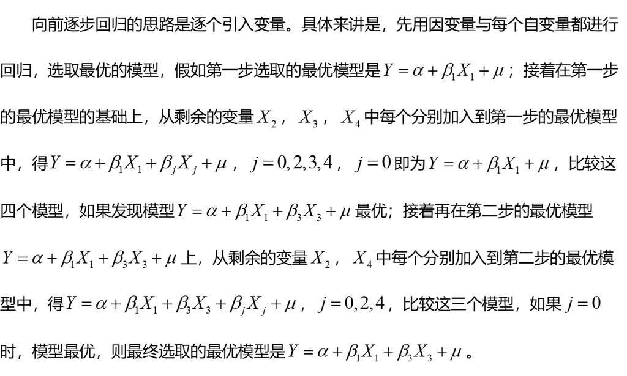

backward逐步回归是先引入所有变量，然后逐个剔除。

both逐步回归是双向的（一切子集回归法，推荐这种方法）。`step(lm, direction = "both")`命令即可进行，省的自己写循环，非常方便。

```r
# 通过若干步比较，得出最优回归模型
lm_step <- step(lm3, direction = "both")
```

```
# Start:  AIC=205.53
# revenue ~ industry + agriculture + construction + consumption +
#     pop + disaster
#
#                Df Sum of Sq      RSS    AIC
# - agriculture   1      6011  5271671 203.55
# - construction  1     31598  5297257 203.62
# - disaster      1    396741  5662400 204.62
# <none>                       5265660 205.53
# - industry      1   1039770  6305430 206.23
# - pop           1   1294061  6559721 206.83
# - consumption   1  10557615 15823275 220.03
#
# Step:  AIC=203.55
# revenue ~ industry + construction + consumption + pop + disaster
#
#                Df Sum of Sq      RSS    AIC
# - construction  1     37130  5308801 201.65
# - disaster      1    742733  6014404 203.52
# <none>                       5271671 203.55
# + agriculture   1      6011  5265660 205.53
# - industry      1   3630106  8901777 209.41
# - pop           1   4733883 10005554 211.16
# - consumption   1  12130608 17402279 219.46
#
# Step:  AIC=201.65
# revenue ~ industry + consumption + pop + disaster
#
#                Df Sum of Sq       RSS    AIC
# - disaster      1    707460   6016261 201.53
# <none>                        5308801 201.65
# + construction  1     37130   5271671 203.55
# + agriculture   1     11544   5297257 203.62
# - industry      1   3889504   9198305 207.90
# - pop           1   6439624  11748425 211.57
# - consumption   1 103394549 108703350 244.94
#
# Step:  AIC=201.53
# revenue ~ industry + consumption + pop
#
#                Df Sum of Sq       RSS    AIC
# <none>                        6016261 201.53
# + disaster      1    707460   5308801 201.65
# + agriculture   1    124145   5892116 203.22
# + construction  1      1857   6014404 203.52
# - industry      1   4820298  10836559 208.36
# - pop           1   7281880  13298142 211.43
# - consumption   1 108630708 114646969 243.74
```

```r
# 所有系数都是显著的
lm_step %>% summary()
```

```
#
# Call:
# lm(formula = revenue ~ industry + consumption + pop, data = dat)
#
# Residuals:
#    Min     1Q Median     3Q    Max
# -919.0 -411.3 -244.3  558.1 1150.7
#
# Coefficients:
#               Estimate Std. Error t value Pr(>|t|)
# (Intercept)  7.168e+04  2.495e+04   2.873  0.01515 *
# industry     1.270e-01  4.279e-02   2.969  0.01277 *
# consumption  6.209e-01  4.406e-02  14.093 2.19e-08 ***
# pop         -7.217e-01  1.978e-01  -3.649  0.00383 **
# ---
# Signif. codes:  0 '***' 0.001 '**' 0.01 '*' 0.05 '.' 0.1 ' ' 1
#
# Residual standard error: 739.5 on 11 degrees of freedom
# Multiple R-squared:  0.9996,  Adjusted R-squared:  0.9995
# F-statistic: 1.033e+04 on 3 and 11 DF,  p-value: < 2.2e-16
```

```r
# 但仍存在多重共线性
DAAG::vif(lm_step, digits = 5)
```

```
#    industry consumption         pop
#     150.870     114.910      11.166
```

### 3.3.2 岭回归

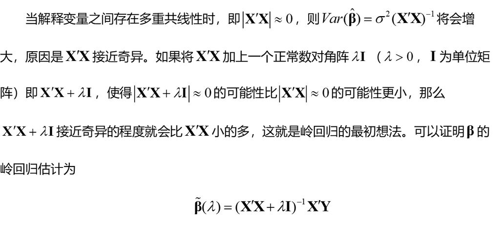

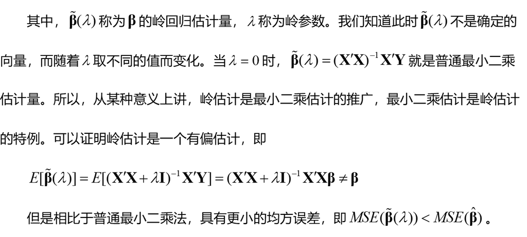

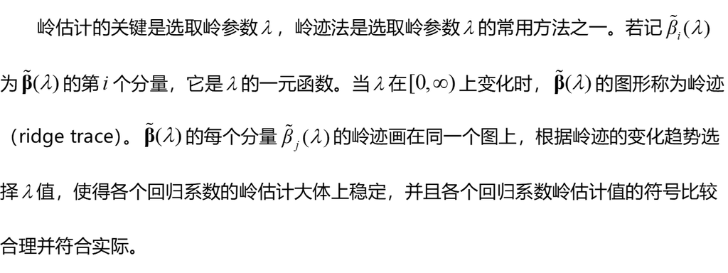

R里MASS包的lm.ridge()函数可以用来做岭估计，其用法与lm()用法类似。不指定$\lambda$时，默认为0

```r
library(MASS)

lm.r <-
  lm.ridge(revenue ~ industry + agriculture + construction + consumption +
             pop + disaster,
           data = dat)
lm.r
```

```
#                    industry   agriculture  construction   consumption
#  6.821406e+04  1.296967e-01 -7.065467e-02  4.465321e-02  6.011086e-01
#           pop      disaster
# -7.020226e-01  4.323570e-02
```

```r
# 岭迹图
plot(
  lm.ridge(
    revenue ~ industry + agriculture + construction + consumption + pop + disaster,
    data = dat,
    lambda = seq(0, 0.3, 0.001)
  ),
  lwd = 3
)

# 给出最佳的\lambda
select(
  lm.ridge(
    revenue ~ industry + agriculture + construction + consumption + pop + disaster,
    data = dat,
    lambda = seq(0, 0.3, 0.001)
  )
)
```

```
# modified HKB estimator is 0.003136352
# modified L-W estimator is 0.002329019
# smallest value of GCV  at 0.004
```

```r
# 使用最佳的\lambda做岭回归
lm.ridge(
  revenue ~ industry + agriculture + construction + consumption + pop + disaster,
  data = dat,
  lambda = 0.004
)
```

```
#                    industry   agriculture  construction   consumption
#  5.662106e+04  1.439691e-01 -3.539058e-03  1.146925e-01  5.037839e-01
#           pop      disaster
# -5.970767e-01  4.829628e-02
```

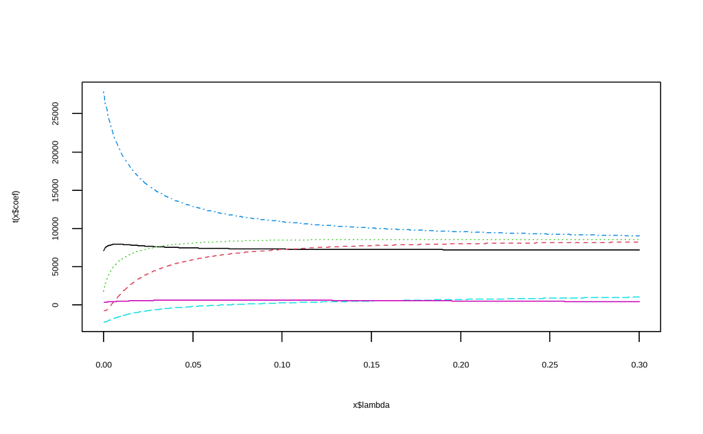

# 4 异方差 hetersdascity

## 4.1 异方差的诊断

### 4.1.1 图示法（定性、粗略）

#### 4.1.1.1 散点图

y对各解释变量作散点图。

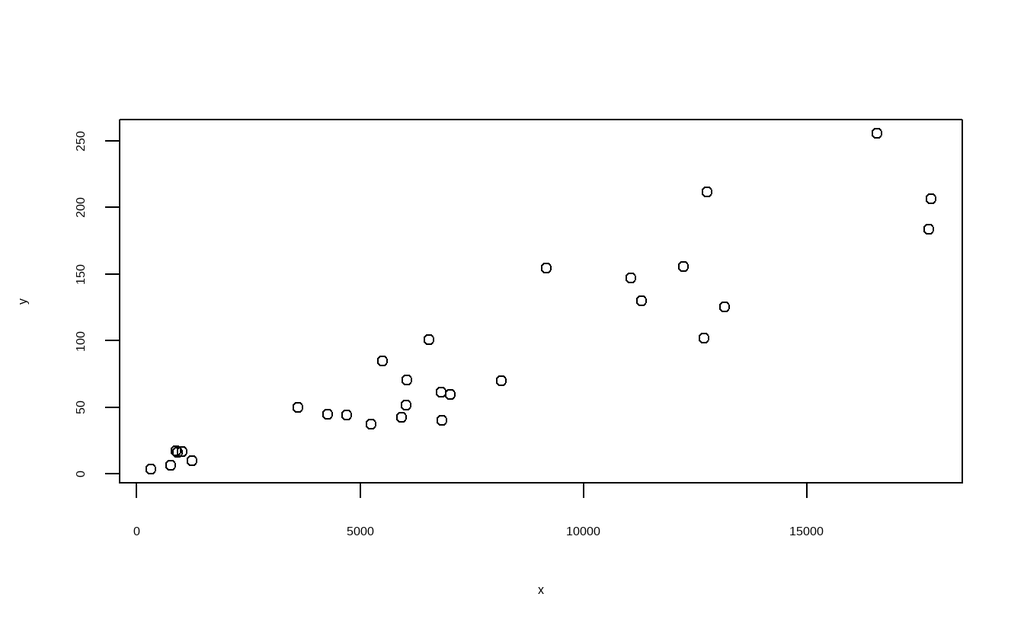

```r
agricul <- read.csv(file = "11-2.csv")
y = agricul[, 2]
x = agricul[, 1]
plot(x, y)
```

散点图的喇叭分布，表明数据存在异方差。 #### 残差图

各解释变量对残差平方或残差绝对值作散点图

```r
lm.a = lm(y ~ x)
summary(lm.a)
```

```
#
# Call:
# lm(formula = y ~ x)
#
# Residuals:
#     Min      1Q  Median      3Q     Max
# -48.924 -21.254   0.527  11.051  59.976
#
# Coefficients:
#               Estimate Std. Error t value Pr(>|t|)
# (Intercept) -5.6610192  8.9241561  -0.634    0.531
# x            0.0123088  0.0009888  12.449 1.07e-12 ***
# ---
# Signif. codes:  0 '***' 0.001 '**' 0.01 '*' 0.05 '.' 0.1 ' ' 1
#
# Residual standard error: 27.06 on 27 degrees of freedom
# Multiple R-squared:  0.8516,  Adjusted R-squared:  0.8461
# F-statistic:   155 on 1 and 27 DF,  p-value: 1.066e-12
```

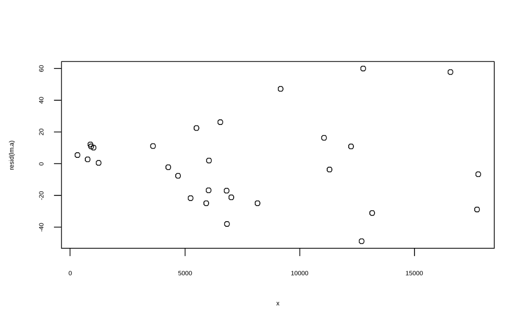

```r
plot(resid(lm.a) ~ x)
```

残差也呈喇叭状分布

### 4.1.2 Goldfeld-Quandt检验

```r
lmtest::gqtest(lm.a, order.by =  ~ x)
```

```
#
#   Goldfeld-Quandt test
#
# data:  lm.a
# GQ = 8.5478, df1 = 13, df2 = 12, p-value = 0.000351
# alternative hypothesis: variance increases from segment 1 to 2
```

显著，拒绝原假设，认为存在异方差。

### 4.1.3 Glejser检验

令残差绝对值对自变量进行对数化的暴力穷举回归，探索它们之间的函数关系。如果有显著的函数关系，即存在异方差。

Glejser 检验的特点是不仅能对异方差的存在进行判断，而且还能对异方差随解释变量变化的函数形式进行诊断。

```r
# 尝试检验一下残差与sqrt(x)的关系，很显著，可见二者存在函数关系
re = resid(lm.a)
abre = abs(re)
summary(lm(abre~I(sqrt(x))))
```

```
#
# Call:
# lm(formula = abre ~ I(sqrt(x)))
#
# Residuals:
#     Min      1Q  Median      3Q     Max
# -28.507  -7.306   1.071   5.551  30.449
#
# Coefficients:
#             Estimate Std. Error t value Pr(>|t|)
# (Intercept) -1.95857    6.94993  -0.282   0.7802
# I(sqrt(x))   0.27861    0.08047   3.462   0.0018 **
# ---
# Signif. codes:  0 '***' 0.001 '**' 0.01 '*' 0.05 '.' 0.1 ' ' 1
#
# Residual standard error: 14.14 on 27 degrees of freedom
# Multiple R-squared:  0.3075,  Adjusted R-squared:  0.2818
# F-statistic: 11.99 on 1 and 27 DF,  p-value: 0.0018
```

```r
summary(lm(abre~-1+I(sqrt(x))))
```

```
#
# Call:
# lm(formula = abre ~ -1 + I(sqrt(x)))
#
# Residuals:
#      Min       1Q   Median       3Q      Max
# -27.6660  -8.5269   0.7122   4.4404  30.8635
#
# Coefficients:
#            Estimate Std. Error t value Pr(>|t|)
# I(sqrt(x))   0.2576     0.0299   8.616 2.32e-09 ***
# ---
# Signif. codes:  0 '***' 0.001 '**' 0.01 '*' 0.05 '.' 0.1 ' ' 1
#
# Residual standard error: 13.91 on 28 degrees of freedom
# Multiple R-squared:  0.7261,  Adjusted R-squared:  0.7163
# F-statistic: 74.23 on 1 and 28 DF,  p-value: 2.317e-09
```

### 4.1.4 White检验

怀特检验的特点是，不仅能够检验异方差的存在，同时在多变量的情况下，还能够判断出是哪一个变量引起的异方差，通常适用于界面数据的情形。

该方法不需要异方差的先验信息，但要求观测值为大样本。

```r
# white检验拒绝原假设，认为存在异方差
lmtest::bptest(lm.a, ~x+I(x^2))
```

```
#
#   studentized Breusch-Pagan test
#
# data:  lm.a
# BP = 8.0196, df = 2, p-value = 0.01814
```

## 4.2 异方差的克服

### 4.2.1 广义最小二乘法

在Glejser检验中，发现残差绝对值与解释变量的函数关系：$\hat \epsilon_i = 0.2576\sqrt X_i$。因此把每个变量都除以$0.2576\sqrt X_i$（变换），消除异方差后再回归。

由此得到的映射关系，需要还原，才能应用于预测。

```r
ys <- y / (0.2576 * sqrt(x))
xs <- x / (0.2576 * sqrt(x))
plot(xs, ys)
lm.sa <- lm(ys ~ xs)
summary(lm.sa)
```

```
#
# Call:
# lm(formula = ys ~ xs)
#
# Residuals:
#     Min      1Q  Median      3Q     Max
# -1.8039 -0.8791 -0.0481  0.6898  2.1778
#
# Coefficients:
#              Estimate Std. Error t value Pr(>|t|)
# (Intercept) -0.099212   0.539252  -0.184    0.855
# xs           0.011824   0.001608   7.351 6.59e-08 ***
# ---
# Signif. codes:  0 '***' 0.001 '**' 0.01 '*' 0.05 '.' 0.1 ' ' 1
#
# Residual standard error: 1.097 on 27 degrees of freedom
# Multiple R-squared:  0.6668,  Adjusted R-squared:  0.6545
# F-statistic: 54.04 on 1 and 27 DF,  p-value: 6.592e-08
```

```
#
#   studentized Breusch-Pagan test
#
# data:  lm.sa
# BP = 3.9989, df = 2, p-value = 0.1354
```

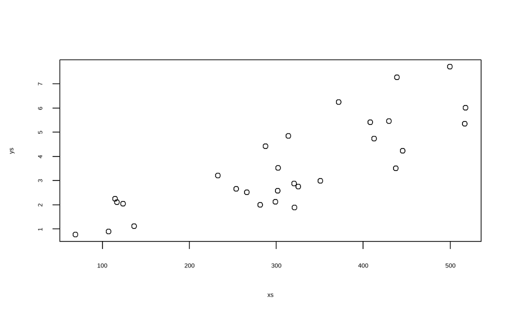

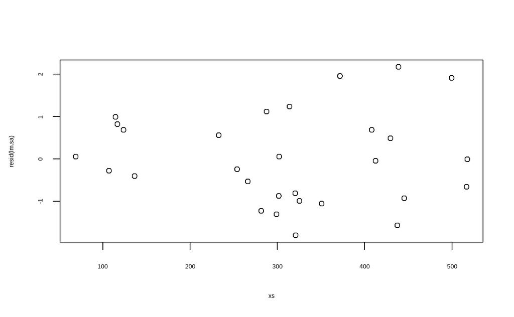

```r
plot(xs, resid(lm.sa))

# white检验通过了，无法拒绝H0
lmtest::bptest(lm.sa,  ~ xs + I(xs ^ 2))
```

### 4.2.2 取对数

```r
lny <- log(y)
lnx <- log(x)
plot(lnx, lny)
lm.lna <- lm(lny ~ lnx)
summary(lm.lna)
```

```
#
# Call:
# lm(formula = lny ~ lnx)
#
# Residuals:
#      Min       1Q   Median       3Q      Max
# -0.62287 -0.25197 -0.02322  0.32754  0.50315
#
# Coefficients:
#             Estimate Std. Error t value Pr(>|t|)
# (Intercept) -4.18013    0.48969  -8.536 3.77e-09 ***
# lnx          0.96253    0.05695  16.901 6.93e-16 ***
# ---
# Signif. codes:  0 '***' 0.001 '**' 0.01 '*' 0.05 '.' 0.1 ' ' 1
#
# Residual standard error: 0.3235 on 27 degrees of freedom
# Multiple R-squared:  0.9136,  Adjusted R-squared:  0.9104
# F-statistic: 285.6 on 1 and 27 DF,  p-value: 6.934e-16
```

```
#
#   studentized Breusch-Pagan test
#
# data:  lm.lna
# BP = 2.5821, df = 2, p-value = 0.275
```

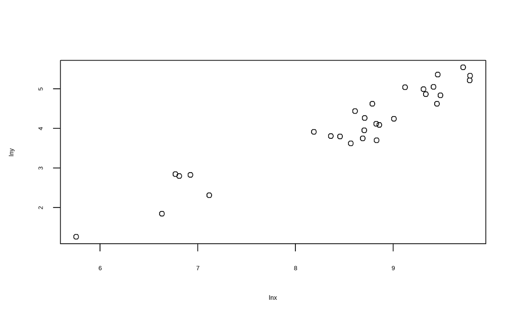

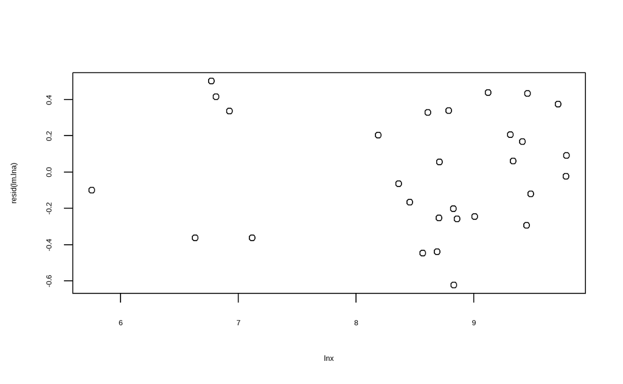

```r
plot(lnx, resid(lm.lna))

lmtest::bptest(lm.lna,  ~ lnx + I(lnx ^ 2))
```

# 5 （误差项之间的）自相关

自相关指**随机误差项**$\epsilon_i$序列之间存在相关性，常见于时间序列数据。

从残差图可以看出残差的变动有系统模式，连续为正和连续为负。另外，从残差前后项之间的散点图可以看出，它们之间存在高度的正的线性关系。这些表明残差项存在一阶正自相关。

```r
dat = read.csv("./11-3.csv")
y = dat$expend
x = dat$income
p = dat$cpi
yp = y / p * 100
xp = x / p * 100
lm.in = lm(yp ~ xp)
summary(lm.in)
```

```
#
# Call:
# lm(formula = yp ~ xp)
#
# Residuals:
#     Min      1Q  Median      3Q     Max
# -27.808  -5.263   1.170   7.195  26.385
#
# Coefficients:
#              Estimate Std. Error t value Pr(>|t|)
# (Intercept) 106.71298   12.20259   8.745 1.06e-07 ***
# xp            0.59989    0.02136  28.090 1.09e-15 ***
# ---
# Signif. codes:  0 '***' 0.001 '**' 0.01 '*' 0.05 '.' 0.1 ' ' 1
#
# Residual standard error: 13.84 on 17 degrees of freedom
# Multiple R-squared:  0.9789,  Adjusted R-squared:  0.9777
# F-statistic: 789.1 on 1 and 17 DF,  p-value: 1.094e-15
```

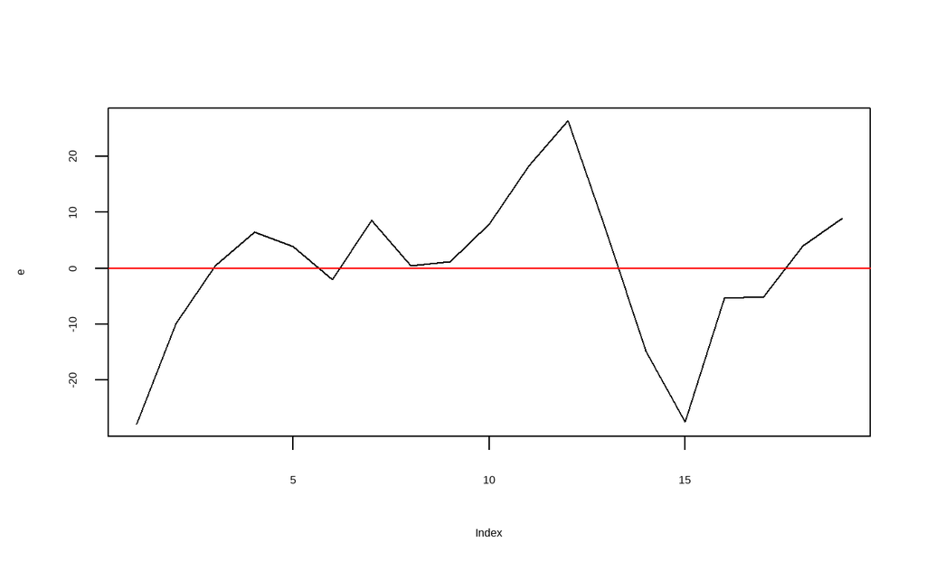

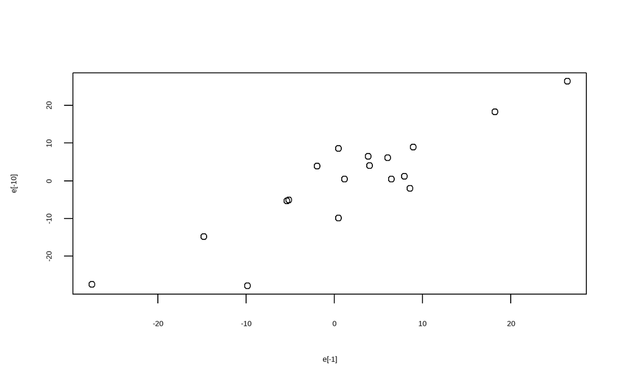

```r
e <- resid(lm.in)
plot(e, type = "l")
abline(h = 0, col = "red")
plot(e[-1], e[-10])
```

## 5.1 自相关的原因

### 5.1.1 模型中未包含一些自相关的重要解释变量

如消费是收入的函数叠加一个随机误差，但现实中，这个误差项中其实包含了一些难以量化的印象因素，而这些影响因素可能并不是随机分布的。如繁荣期，人们预期乐观，误差项就会为正；萧条期，人们悲观，误差项为负。

### 5.1.2 变量惯性

如蛛网模型导致农产品产量和价格呈现跨期负相关。

## 5.2 自相关的诊断

### 5.2.1 图示法

残差序列图或者残差散点图。在残差散点图中，集中于1、3象限为正自相关；集中于2、4象限为负自相关。

### 5.2.2 Durbin-Watson(DW)检验

检验随机误差项之间是否存在一阶自相关。

```r
dw <- lmtest::dwtest(lm.in)
dw
```

```
#
#   Durbin-Watson test
#
# data:  lm.in
# DW = 0.76951, p-value = 0.0003449
# alternative hypothesis: true autocorrelation is greater than 0
```

## 5.3 自相关的克服

如果序列相关是由于错误地设定模型的数学形式所致，那么就应当修改模型的数学形式。

如果序列相关是由于模型中省略了重要解释变量造成的，那么解决办法就是找出略去的解释变量，把它做为重要解释变量列入模型。

只有当以上两种引起序列相关的原因都消除后，才能认为误差项 “真正”存在序列相 关。然后使用广义差分法得到新的系数。

```r
# 结果不仅给出了新的系数，还给出了D-W检验的前后比较，从显著到不显著。可以认为自相关性基本消除。
orcutt::cochrane.orcutt(lm.in)
```

```
# Cochrane-orcutt estimation for first order autocorrelation
#
# Call:
# lm(formula = yp ~ xp)
#
#  number of interaction: 8
#  rho 0.497334
#
# Durbin-Watson statistic
# (original):    0.76951 , p-value: 3.449e-04
# (transformed): 1.39817 , p-value: 5.236e-02
#
#  coefficients:
# (Intercept)          xp
#  119.898510    0.583394
```

# 6 虚拟变量回归模型